Copyright (c) 2020 Python Charmers. Please do not distribute.

# Intermediate Python for Engineers - Day 2

# Setup

Here are some setup instructions:

## Browser

Please use Chrome or Firefox or Safari. *Preferably not IE or Edge*.

## Jupyter notebook server

1. Go to https://hub.pythoncharmers.com/
2. Your username is your email address
3. The password is the same as you used to log in to Zulip and is in the setup email.

## Load up your notebook

- It will be called "Yourname Day 2.ipynb".
- Save it (Control-S or File | Save Notebook).

We'll give more instructions on getting started with the notebooks as we start the course.

## Zulip chat server

1. Go to https://pythoncharmers.zulipchat.com
2. **Test:** Please send a message to our stream (#**485 Python for Engineers** ) saying Hi!

## Resources

- Please download the course materials PDF (in your home folder)
- You may also download the `.zip` file containing the Jupyter Notebooks of the course materials

## Trainer notebook

We suggest that you load up the trainer's notebook from the Trainer folder in a separate browser tab and reload when needed.

(To do this, right-click the file, then choose "Open in New Browser Tab". Then hit F5 or Command-R whenever you want to see the latest version of the trainer's notebook.)

### Session 2: Further language features

Session 2 will teach you further Python language features and explain important distinctions and “gotchas” that help you with developing robust, efficient systems in Python:

- Lazy sequences (continued)
- When & how to use decorators
  - Worked example: writing a disk-backed caching decorator
  - Properties, class methods
- Context managers:
  - Managing state; streamlining exception handling
  - Worked example: elegant code beyond PEP8 with context managers
- Managing memory
  - Mutability vs immutability
  - Memory profiling; garbage collection

## Feedback

- Any questions?
- Any special requests?

## Lazy sequences

### Exercise solution (Laurent)

```python
# This simple syntax:
# for a in thing:
#     print(a)
# ...
# is very similar to this:

iterator = iter(thing)
while True:
    try:
        a = next(iterator)
    except StopIteration:
        break
    print(a)
```

```python
from calendar import isleap

class LeapYearSequence:
    def __init__(self, start):
        self._cur = start - 1

    def __iter__(self):
        return self

    def __next__(self):
        while True:
            x = self._cur
            self._cur += 1
            if isleap(x):
                break
        return x
```

Goal

```python
list(enumerate('ABC', ))
```

```
[(0, 'A'), (1, 'B'), (2, 'C')]
```

```python
some_list[:10]
```

```python
from itertools import islice

list(islice(LeapYearSequence(start=2010), 10))
```

```
[2012, 2016, 2020, 2024, 2028, 2032, 2036, 2040, 2044, 2048]
```

Another way:

```python
import toolz as tz

list(tz.take(5, LeapYearSequence(start=2010)))
```

```python
for i, leap_year in enumerate(LeapYearSequence(start=2010)):
    print(leap_year)
    if i > 10:
        break
```

```
2012
2016
2020
2024
2028
2032
2036
2040
2044
2048
2052
2056
```

### Generator functions

A generator is an easy mechanism to construct an iterable.

A generator function returns a generator when called.

```python
import math
```

```python
from calendar import isleap
```

```python
def leap_years(start, end=None):
    print('Starting function ...')
    if end is None:
        end = math.inf
    year = start - 1
    while year < end:
        year += 1
        if isleap(year):
            print('About to yield ...')
            yield year
            print('Resuming function ...')
    print('Ending function')
```

```python
years = leap_years(2000, 2040)
```

```python
years
```

```
<generator object leap_years at 0x7f492cb5f270>
```

```python
next(years)
```

```
Starting function ...
About to yield ...
```

```
2000
```

```python
next(years)
```

```
Resuming function ...
About to yield ...
```

```
2004
```

```python
next(years)
```

```
Resuming function ...
About to yield ...
```

```
2008
```

```python
list(years)
```

```
Resuming function ...
About to yield ...
Resuming function ...
About to yield ...
Resuming function ...
About to yield ...
Resuming function ...
About to yield ...
Resuming function ...
About to yield ...
Resuming function ...
About to yield ...
Resuming function ...
About to yield ...
Resuming function ...
About to yield ...
Resuming function ...
Ending function
```

```
[2012, 2016, 2020, 2024, 2028, 2032, 2036, 2040]
```

```python
list(years)
```

```
[]
```

### Exercise

1. Create a generator function for the days of the week (Mon-Fri).
2. Create a generator function for an infinite sequence of days of the week.

```python
def weekdays():
    yield 'Mon'
    yield 'Tues'
    yield 'Wed'
    yield 'Thurs'
    yield 'Fri'
    # Implied: return None
```

```python
w = weekdays()
```

```python
next(w)
```

[output not shown]

```python
def weekdays():
    days = ('Mon', 'Tues', 'Wed', 'Thurs', 'Fri')
    for day in days:
        yield day
```

```python
list(weekdays())
```

```
['Mon', 'Tues', 'Wed', 'Thurs', 'Fri']
```

```python
def inf_weekdays():
    days = ('Mon', 'Tues', 'Wed', 'Thurs', 'Fri')
    while True:
        for day in days:
            yield day
```

```python
list(tz.take(11, inf_weekdays()))
```

```
['Mon',
 'Tues',
 'Wed',
 'Thurs',
 'Fri',
 'Mon',
 'Tues',
 'Wed',
 'Thurs',
 'Fri',
 'Mon']
```

### Example: Monte Carlo simulation

[figure not shown]

If you simulate many points (x, y) in the unit square and count the proportion that lie in the circle, that's your estimate for $\pi / 4$.

Example: 0.75 of the points are red.

Estimate for $\pi$: $4 \times 0.75 = 3$

```python
import random
```

```python
from typing import Iterable
```

```python
def estimate_pi_gen() -> Iterable:
    k = 0
    n = 0
    while True:
        x = random.random()
        y = random.random()
        if x**2 + y**2 < 1:
            k += 1
        n += 1
        yield k / n * 4
```

```python
pi = estimate_pi_gen()
```

```python
pi
```

```
<generator object estimate_pi_gen at 0x7f492ce39c80>
```

```python
next(pi)
```

```
3.217391304347826
```

```python
tz.nth(10**5, pi)
```

```
3.144881905504413
```

### Exercise

1. Google "toolz python"
2. use toolz to sum up the total file sizes by extension in the `/Data` folder.

Example output:

`{'.txt': 23748234, 'gz': 27321, ...}`

Hints:

```python
from pathlib import Path

data_folder = Path('/Data')
```

```python
# Check out data_folder.glob?
```

```python
paths = list(data_folder.glob('*'))    # rglob for recursive search ...
```

```python
import os

os.path.isfile('/Data')
```

```
False
```

```python
files = list(filter(os.path.isfile, paths))
```

Helper functions:

```python
def get_ext(path):
    return path.suffix

def get_filesize(path):
    return path.stat().st_size
```

Another hint: look at `toolz.groupby`

```python
import toolz as tz
```

```python
>>> names = ['Alice', 'Bob', 'Charlie', 'Dan', 'Edith', 'Frank']
>>> tz.groupby(len, names)
```

```
{5: ['Alice', 'Edith', 'Frank'], 3: ['Bob', 'Dan'], 7: ['Charlie']}
```

```python
paths_by_ext = tz.groupby(get_ext, files)
```

```python
def count_size_by_extension(paths_by_ext: dict) -> dict:
    return {extension: sum(get_filesize(file) for file in files)
            for extension, files in paths_by_ext.items()}
```

```python
count_size_by_extension(paths_by_ext)
```

```
{'.txt': 4810857,
 '.gexf': 120238,
 '.hdf': 476544,
 '.pdf': 13947496,
 '.zip': 5274816,
 '.csv': 19871826,
 '.bz2': 10575422,
 '.xlsx': 1658671,
 '.sqlite': 12931072,
 '.jpg': 489445,
 '.xz': 138236,
 '.png': 2255125,
 '.h5': 25877534,
 '.parquet': 4156633,
 '.xls': 3543040,
 '.hdf5': 176120,
 '.json': 207544,
 '.gz': 9334755,
 '': 9,
 '.bin': 12288,
 '.ipynb': 11733,
 '.mat': 61832,
 '.npz': 1436}
```

### Other options

```python
sum_filesizes2 = tz.compose(sum, tz.partial(map, get_filesize))
```

```python
print(sum_filesizes2(paths_by_ext['.csv']))
```

```
19871826
```

```python
from toolz.curried import map as cmap

sum_filesizes3 = tz.pipe(paths_by_ext['.csv'],
                         cmap(get_filesize),
                         sum)
```

```python
sum_filesizes3
```

```
19871826
```

### Suggested homework: familiarize yourself with the `toolz` API.

```python
%load Materials/solutions/total_filesize_by_ext.py
```

### Exercise: find all duplicate files in the Data folder non-recursively

Hint: use the `get_hash()` function from yesterday.

```python
import hashlib

def get_hash(filename):
    """Read the given file's contents and return the MD5 checksum.

    If the file doesn't exist, raise an exception.
    """
    path = Path(filename)
    data = path.read_bytes()
    hasher = hashlib.md5(data)   # pass a byte-string
    return hasher.hexdigest()

get_hash('/Data/abalone.csv')
```

```
'ecaa7849df6596350b8669eee47bedaa'
```

Try grouping by your get_hash function

### Solution

```python
hashes = {file: get_hash(file) for file in files}
```

```python
# "Invert" the dictionary:
hashes_inv = tz.groupby(hashes.get, hashes)
```

```python
capitals_dict = {'Netherlands': 'Amsterdam',
                 'USA': 'Washington, DC'}
```

```python
capitals_dict.get('Netherlands')
```

```
'Amsterdam'
```

```python
hashes_inv
```

```
{'ddbbeec4048a358264d3198f19edb930': [PosixPath('/Data/solar_irradiance.txt')],
 '786b27318f6b3160a3cbba25f7c83fbe': [PosixPath('/Data/us_cities.gexf')],
 '1cba80daf98866706503f93836a61000': [PosixPath('/Data/HousePricesVsInterestRates.hdf')],
 'c9d59298c42bc9669cf7c5871417681e': [PosixPath('/Data/Prospectus.pdf')],
 'ded479abb64c09f48b48ceb135fa80ac': [PosixPath('/Data/patents.zip')],
 'ebb9b6042737c98b54be95bf492fc9f2': [PosixPath('/Data/peak_sunlight_hours.csv')],
 '77d14ed7ff736a08fd5c59fff0f03d26': [PosixPath('/Data/sampled_tesla.csv')],
 '5baabc53058679761489a5a81d9e6221': [PosixPath('/Data/surnames.csv')],
 '7d89b96ca081adc75e6946f4a1d7236e': [PosixPath('/Data/maugham_the_verger.txt')],
 'c343b383a61c982eb40d51f58a12654c': [PosixPath('/Data/housing-data-10000.csv.bz2')],
 'f24da0f054e25b3d216dc0fd073a78d1': [PosixPath('/Data/Converted_FPIs.xlsx')],
 'dafa785d1742dd4930eb866095e96630': [PosixPath('/Data/places.sqlite')],
 '8e407deaf0d6004855d4dab6103f8b0a': [PosixPath('/Data/hot-air-balloon1.jpg')],
 '6f70277a955fe7b28acd62977205b8ff': [PosixPath('/Data/NBA_standings.xlsx')],
 '930e1b676b95a0cce9a14728abe282f0': [PosixPath('/Data/Kavita.pdf')],
 '4e1aed470953daedd5db1294f7c9f3c2': [PosixPath('/Data/melb_monthly_weather_086071.csv')],
 '47b09b47a0192d10f5d5045346e55dbc': [PosixPath('/Data/random_names_emails.csv.xz')],
 'eff8d2abc2b6d2d0bc40ba9cd3a4693d': [PosixPath('/Data/airports.sqlite')],
 '4aa95fa794fa7d05bb3f8dcfa5bd9c4e': [PosixPath('/Data/Marcie.png')],
 'd41d8cd98f00b204e9800998ecf8427e': [PosixPath('/Data/Airports.sqlite'),
  PosixPath('/Data/response.xlsx')],
 '326db9d8553896b75e0a75d7e8f9f554': [PosixPath('/Data/stocks_missing_data.h5')],
 'eff91b980c25ce0e5adbb1813170aa81': [PosixPath('/Data/NL_public_holidays.parquet')],
 'feb27bd4f6e27d1f9c5cb90e2164e65a': [PosixPath('/Data/interest_inflation_aud.csv')],
 '2dcd3f733267e3c0461fb9e4543d714f': [PosixPath('/Data/iehova.gexf')],
 'd48f818bf32d859f74190f3a0227a1f8': [PosixPath('/Data/inflation.hdf')],
 '8d1cc2ceea5c63e650e4d314250efdd3': [PosixPath('/Data/bank-small.csv')],
 'd282d196363580c4eaf8e3c262c4656c': [PosixPath('/Data/gapminder-health-income.csv')],
 'c64001009e396ea65a5fb6748588acb8': [PosixPath('/Data/alice_mask.png')],
 '43c2f8bef508e349965e6206b03d63e5': [PosixPath('/Data/domestic_airline_activity.xls')],
 '02fafd67a81c385ba20cbbb7cf753cd1': [PosixPath('/Data/animals2.hdf5')],
 'd318d1eb8fda6e01030811aef67ed886': [PosixPath('/Data/States.json')],
 '5b39ee02a992214bdc2089af830360fa': [PosixPath('/Data/reconcile_tsla.hdf5')],
 'ecaa7849df6596350b8669eee47bedaa': [PosixPath('/Data/abalone.csv')],
 '973c626bae65404e5974def1a8d825fb': [PosixPath('/Data/stock_symbols.jl.bz2')],
 'adf963f23eeae84b6adde8b52231b6d3': [PosixPath('/Data/calories.csv')],
 '8f36a0ed26169c75c5095030723190b6': [PosixPath('/Data/LIBOR.csv')],
 'c8c9ac48212d89e8effaf979d983caf4': [PosixPath('/Data/bank-full.csv.bz2')],
 'acdb7543fc984ee7e807b293c6eb6afa': [PosixPath('/Data/heights_and_weights.csv')],
 '0e4fac7187885a87ffd10e13c4ce9911': [PosixPath('/Data/words_alpha.txt')],
```

[output cut: 71 more lines]

```
 '9cfdb2f0318a81bcfed3f19fbb5fad87': [PosixPath('/Data/USStatesData.zip')],
 '95623e632d2de5816c9525b6b02bf413': [PosixPath('/Data/big-mac-full-index.csv')],
 'b459cdb12cf0f84d52cf83ae16c7ad10': [PosixPath('/Data/alice_in_wonderland.txt')],
 'efe14fbc8dada32aa0564b705cfa3505': [PosixPath('/Data/alice_one_time_pad.txt')],
 '2b6c25a2237c0c2ab3cfc7af55fc45f7': [PosixPath('/Data/hdr14_statisticaltables.xlsx')],
 'b6ede9af6f549c310aed835fb91b4fe4': [PosixPath('/Data/neiss_clean.h5')],
 'ca1b93c0b1f69689e92ee4920e6ef07b': [PosixPath('/Data/corrupted.bin')],
 '4044e2839de128940993f91c6a8a778a': [PosixPath('/Data/portfolio_flat.h5')],
 '654e06acb0ccf197f706bdac47e0ee58': [PosixPath('/Data/usd_reserves.hdf5')],
 'fc5a8c4bb42dc10f49136b6ea09ff505': [PosixPath('/Data/abalone.xlsx')],
 'b267733444c5898bd117cc9da8ef2178': [PosixPath('/Data/boston.csv')],
 '4ca3999aa96212a7fd0ce30e037f5f7c': [PosixPath('/Data/basketball.csv')],
 'd2c646875b9f33232d3b9fb96826b799': [PosixPath('/Data/airports_clean.csv.gz')],
 '40836c03a1a2ab405710c52249137392': [PosixPath('/Data/zen.utf16.txt')],
 '65da5c806971da0c7df8f0cd0842bb21': [PosixPath('/Data/olympics2012.csv')]}
```

```python
hashes_inv = tz.groupby(get_hash, files)
```

```python
result = tz.valfilter(lambda data: len(data) > 1, hashes_inv.)
```

```python
result = list(filter(lambda filelist: len(filelist) > 1, hashes_inv.values()))
```

```python
result
```

```
[[PosixPath('/Data/Airports.sqlite'), PosixPath('/Data/response.xlsx')],
 [PosixPath('/Data/big-mac-2020-01-14.xls'), PosixPath('/Data/big-mac.xls')],
 [PosixPath('/Data/melbourne-temp.csv'), PosixPath('/Data/bundoora-temp.csv')],
 [PosixPath('/Data/forbes.csv'), PosixPath('/Data/forbes1964.csv')]]
```

```python
for value in hashes_inv.values():
    if len(value) > 1:
        print(value)
```

```
[PosixPath('/Data/Airports.sqlite'), PosixPath('/Data/response.xlsx')]
[PosixPath('/Data/big-mac-2020-01-14.xls'), PosixPath('/Data/big-mac.xls')]
[PosixPath('/Data/melbourne-temp.csv'), PosixPath('/Data/bundoora-temp.csv')]
[PosixPath('/Data/forbes.csv'), PosixPath('/Data/forbes1964.csv')]
```

### Generator expression

```python
def leap_years(start, end):
    for year in range(start, end):
        if isleap(year):
            yield year
```

```python
years = leap_years(2000, 2020)
```

Equivalent:

```python
years = (year for year in range(2000, 2020) if isleap(year))
```

Comprehensions:

$$ \{ k^2: k \in Z \text{if k is odd} \} $$

Equivalent:

```python
list(year for year in range(2000, 2020) if isleap(year))
```

```python
[year for year in range(2000, 2020) if isleap(year)]
```

### Performance note

`toolz`: will be faster than using Pandas dataframes ...

Python dictionaries are highly optimized.

## Decorators

#### Examples

```python
from numba import jit
```

```python
@jit
def dot(x, y):
    total = 0
    for xi, yi in zip(x, y):
        total += xi * yi
    return total
```

```python
import numpy as np
```

```python
x, y = np.random.normal(size=(2, 10**6))
```

```python
len(x), len(y)
```

```
(1000000, 1000000)
```

```python
%timeit dot(x, y)
```

```
1.26 ms ± 28.3 µs per loop (mean ± std. dev. of 7 runs, 1 loop each)
```

```python
%timeit np.dot(x, y)
```

```
672 µs ± 88.8 µs per loop (mean ± std. dev. of 7 runs, 1000 loops each)
```

#### Jupyter magic commands

```python
%timeit?
```

[output not shown]

[output cut: 19 more lines]

```
  In [4]: %timeit -r 4 u == None

  In [5]: import time

  In [6]: %timeit -n1 time.sleep(2)


The times reported by %timeit will be slightly higher than those
reported by the timeit.py script when variables are accessed. This is
due to the fact that %timeit executes the statement in the namespace
of the shell, compared with timeit.py, which uses a single setup
statement to import function or create variables. Generally, the bias
does not matter as long as results from timeit.py are not mixed with
those from %timeit.
File:      /opt/conda/lib/python3.8/site-packages/IPython/core/magics/execution.py
```

```python
%lsmagic
```

```
Available line magics:
%alias  %alias_magic  %autoawait  %autocall  %automagic  %autosave  %bookmark  %cat  %cd  %clear  %colors  %conda  %config  %connect_info  %cp  %debug  %dhist  %dirs  %doctest_mode  %ed  %edit  %env  %gui  %hist  %history  %killbgscripts  %ldir  %less  %lf  %lk  %ll  %load  %load_ext  %loadpy  %logo…

Available cell magics:
%%!  %%HTML  %%SVG  %%bash  %%capture  %%debug  %%file  %%html  %%javascript  %%js  %%latex  %%markdown  %%perl  %%prun  %%pypy  %%python  %%python2  %%python3  %%ruby  %%script  %%sh  %%svg  %%sx  %%system  %%time  %%timeit  %%writefile

Automagic is ON, % prefix IS NOT needed for line magics.
```

#### Example 2: web apps with Flask

```python
from flask import Flask
app = Flask(__name__)

@app.route('/')
def hello_world():
    return 'Hello, World!'
```

### Example 3: caching results of function calls

```python
from functools import lru_cache
```

```python
@lru_cache
def fetch_market_data(start_date, end_date):
    # Slow code here to read the db etc.
    ...
```

### How decorators work

```python
def make_bold(func):
    def inner(*args):
        print(type(args), args)
        return '<b>' + func(*args) + '</b>'
    # Important:
    return inner
```

```python
def hello(name):
    return f'Hello {name}!'
```

```python
bold_hello = make_bold(hello)
```

```python
bold_hello('Ed')
```

```
<class 'tuple'> ('Ed',)
```

```
'<b>Hello Ed!</b>'
```

#### Decorator syntax with `@`:

These are equivalent:

```python
@make_bold
def hello():
    return 'Hello!'
```

```python
def hello():
    return 'Hello!'
hello = make_bold(hello)
```

### Exercise:

1. Write a `timeme` decorator that prints to stdout how long a function takes to run.

Hint: use `time.time()` to get the current system time.

```python
import time

time.time()
```

```
1603180010.9761195
```

### Question: how to write a function decorator that takes arguments?

You define a callable (with arguments) that returns a decorator callable (function or object with a `__call__` method).

```python
lru_cache??
```

```
Signature: lru_cache(maxsize=128, typed=False)
Source:
def lru_cache(maxsize=128, typed=False):
    """Least-recently-used cache decorator.

    If *maxsize* is set to None, the LRU features are disabled and the cache
    can grow without bound.

    If *typed* is True, arguments of different types will be cached separately.
    For example, f(3.0) and f(3) will be treated as distinct calls with
    distinct results.

    Arguments to the cached function must be hashable.

    View the cache statistics named tuple (hits, misses, maxsize, currsize)
    with f.cache_info().  Clear the cache and statistics with f.cache_clear().
    Access the underlying function with f.__wrapped__.

    See:  http://en.wikipedia.org/wiki/Cache_replacement_policies#Least_recently_used_(LRU)

    """

    # Users should only access the lru_cache through its public API:
    #       cache_info, cache_clear, and f.__wrapped__
    # The internals of the lru_cache are encapsulated for thread safety and
    # to allow the implementation to change (including a possible C version).

    if isinstance(maxsize, int):
        # Negative maxsize is treated as 0
        if maxsize < 0:
            maxsize = 0
    elif callable(maxsize) and isinstance(typed, bool):
        # The user_function was passed in directly via the maxsize argument
        user_function, maxsize = maxsize, 128
        wrapper = _lru_cache_wrapper(user_function, maxsize, typed, _CacheInfo)
        return update_wrapper(wrapper, user_function)
    elif maxsize is not None:
        raise TypeError(
            'Expected first argument to be an integer, a callable, or None')

    def decorating_function(user_function):
        wrapper = _lru_cache_wrapper(user_function, maxsize, typed, _CacheInfo)
        return update_wrapper(wrapper, user_function)

    return decorating_function
File:      /opt/conda/lib/python3.8/functools.py
Type:      function
```

### Solution (Rob)

```python
def timeme(func):
    def inner(*args, **kwargs):
        print(kwargs)
        start_time = time.time()
        result = func(*args, **kwargs)
        end_time = time.time()
        print(f"Time passed {end_time - start_time}")
        return result
    return inner
```

```python
@timeme
def hello(text, sleep=1):
    time.sleep(sleep)
    return text
```

```python
hello('Rob', sleep=2)
```

[output not shown]

```
'Rob'
```

```python
@bounded(3, 4)
def square(x):
    return x**2
```

### Exercise: try implementing this

Hint: you’ll need a function that returns a decorator with the same structure as `make_bold`.

Solution: see `solutions/bounded_decorator.py`

### Break for 20 minutes (until 10.15am)

## Context managers

You can define classes that implement the "context manager protocol" for use with the `with` statement

#### File example

```python
with open('new_file.txt', 'wt') as file:
    file.write('data')
```

#### Matplotlib XKCD plots

```python
import matplotlib.pyplot as plt
```

```python
import pandas as pd
```

```python
medals = pd.read_csv('/Data/olympics2012.csv').set_index('Country')
```

```python
medals[:3]
```

| Country | Gold | Silver | Bronze |
| --- | --- | --- | --- |
| Afghanistan | 0 | 0 | 1 |
| Albania | 0 | 0 | 0 |
| Algeria | 1 | 0 | 0 |

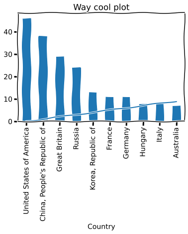

```python
with plt.xkcd() as thing:
    plt.plot(range(10))
    plt.title('Way cool plot')
    medals['Gold'].nlargest(10).plot(kind='bar')
```

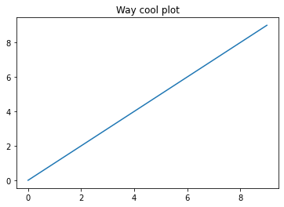

```python
plt.plot(range(10))
plt.title('Way cool plot');
```

#### Other examples:

- creating temporary files
- database connections that you want to close automatically
- etc.

```python
class CM:
    def __enter__(self):
        print('__enter__')
        return self

    def __exit__(self, *args):
        print('__exit__')

    def hello(self):
        print('Hello')
```

```python
with CM() as obj:
    1 / 0
    obj.hello()
```

[output not shown]

```
---------------------------------------------------------------------------
ZeroDivisionError                         Traceback (most recent call last)
<ipython-input-284-e7349a41b5f0> in <module>
      1 with CM() as obj:
----> 2     1 / 0
      3     obj.hello()

ZeroDivisionError: division by zero
```

```python
class Simple:
    def hello(self):
        print('Hello')
```

```python
from contextlib import contextmanager   # decorator you apply to a gen function

@contextmanager
def context_hello():
    # __enter__ block
    print('__enter__')

    yield

    # __exit__ block
    print('__exit__')
```

```python
@contextmanager
def context_hello():
    # __enter__ block
    print('__enter__')

    try:
        yield Simple()
    except Exception as e:
        print(e)

    # __exit__ block
    print('__exit__')
```

```python
with context_hello() as obj:
    1 / 0
    obj.hello()
```

```
__enter__
division by zero
__exit__
```

### Exercise:

Write a context manager to temporarily change the working directory

Following the pattern above write your own context manager called `move_directory` to change directory for the duration of the with statement. Look at os.chdir and os.getcwd for changing the Python process’ working environment.

Test this with:

```python
with move_directory('Data'):
    forbes = pd.read_csv('forbes.csv')

forbes[:3]
```

### Solution (Laurent)

```python
@contextmanager
def move_directory(path):
    old_cwd = os.getcwd()
    os.chdir(path)

    try:
        yield
    except Exception as e:
        print(e)

    os.chdir(old_cwd)
```

```python
# from IPython.display import display
```

```python
display
```

```
<function IPython.core.display.display(*objs, include=None, exclude=None, metadata=None, transient=None, display_id=None, **kwargs)>
```

```python
import pandas as pd

print(os.getcwd())
with move_directory('/Data'):
    print(os.getcwd())
    forbes = pd.read_csv('forbes.csv')

display(forbes[:3])

print(os.getcwd())
```

```
/home/jovyan
/home/data/Data
```

|  | rank | name | country | sales | profits | assets | marketvalue |
| --- | --- | --- | --- | --- | --- | --- | --- |
| 0 | 1 | Citigroup | United States | 94.71 | 17.85 | 1264.03 | 255.30 |
| 1 | 2 | General Electric | United States | 134.19 | 15.59 | 626.93 | 328.54 |
| 2 | 3 | American Intl Group | United States | 76.66 | 6.46 | 647.66 | 194.87 |

```
/home/jovyan
```

#### Alternative solution (Marco):

```python
class MoveDirectory:
    def __init__(self, path):
        self.newdir = path

    def __enter__(self):
        print('__enter__')
        self.curr = os.getcwd()
        os.chdir(self.newdir)
        return self

    def __exit__(self, *args):
        print('__exit__')
        os.chdir(self.curr)
```

```python
print(f"before pwd: {os.getcwd()}")
with MoveDirectory('/Data') as obj:
    print(f"inside pwd: {os.getcwd()}")
    forbes = pd.read_csv('forbes.csv')

print(f"after pwd: {os.getcwd()}")
```

```
before pwd: /home/jovyan
__enter__
inside pwd: /home/data/Data
__exit__
after pwd: /home/jovyan
```

```python
forbes
```

|  | rank | name | country | sales | profits | assets | marketvalue |
| --- | --- | --- | --- | --- | --- | --- | --- |
| 0 | 1 | Citigroup | United States | 94.71 | 17.85 | 1264.03 | 255.30 |
| 1 | 2 | General Electric | United States | 134.19 | 15.59 | 626.93 | 328.54 |
| 2 | 3 | American Intl Group | United States | 76.66 | 6.46 | 647.66 | 194.87 |
| 3 | 4 | ExxonMobil | United States | 222.88 | 20.96 | 166.99 | 277.02 |
| 4 | 5 | BP | United Kingdom | 232.57 | 10.27 | 177.57 | 173.54 |
| ... | ... | ... | ... | ... | ... | ... | ... |
| 1961 | 1996 | Siam City Bank | Thailand | 0.48 | 0.02 | 11.27 | 1.47 |
| 1962 | 1997 | Yokogawa Electric | Japan | 2.78 | -0.22 | 2.96 | 3.29 |
| 1963 | 1998 | Hindalco Industries | India | 1.35 | 0.14 | 2.47 | 2.76 |
| 1964 | 1999 | Nexans | France | 5.09 | 0.00 | 2.71 | 0.88 |
| 1965 | 2000 | Oriental Bank of Commerce | India | 0.81 | 0.10 | 7.16 | 1.17 |

1966 rows × 7 columns

## 2 more decorators re classes

### `@property`

```python
class BankAccount:
    def __init__(self, balance=0):
        self.__balance = balance

    def withdraw(self, amount):
        self.__balance -= amount

#     # In Java:
#     def get_balance(self):
#         return self.__balance

    # In Python, you'd prefer properties:
    @property
    def balance(self):
        print('calling the balance property ...')
        return self.__balance
```

```python
bills_account = BankAccount(8.4e10)
```

```python
# bills_account.get_balance()
```

```python
bills_account.balance    # descriptors
```

```
calling the balance property ...
```

```
84000000000.0
```

#### Read-only currently

```python
bills_account.balance = 100
```

```
---------------------------------------------------------------------------
AttributeError                            Traceback (most recent call last)
<ipython-input-349-2bed4457407c> in <module>
----> 1 bills_account.balance = 100

AttributeError: can't set attribute
```

#### Setter

```python
class BankAccount:
    def __init__(self, balance=0):
        self.__balance = balance

    def withdraw(self, amount):
        self.__balance -= amount

#     # In Java:
#     def get_balance(self):
#         return self.__balance

    # In Python, you'd prefer properties:
    @property
    def balance(self):
        print('calling the balance property ...')
        return self.__balance

    @balance.setter
    def balance(self, new_value):
        print('calling the balance setter ...')
        self.__balance = new_value
```

```python
bills_account = BankAccount(8.4e10)
```

```python
bills_account.balance    # descriptors
```

```
calling the balance property ...
```

```
84000000000.0
```

```python
bills_account.balance = 100
```

```
calling the balance setter ...
```

#### Question: are data classes read-only by default?

No, but you can set this:

```python
from dataclasses import dataclass

@dataclass(frozen=True)
class Card:
    rank: str
    suit: str
```

```python
c = Card('A', 'hearts')
```

```python
c.rank = '10'
```

```
---------------------------------------------------------------------------
FrozenInstanceError                       Traceback (most recent call last)
<ipython-input-357-a60bfc126461> in <module>
----> 1 c.rank = '10'

<string> in __setattr__(self, name, value)

FrozenInstanceError: cannot assign to field 'rank'
```

### Question: do you need to use properties to wrap another variable?

No.

```python
from dataclasses import dataclass

@dataclass(frozen=True)
class Card:
    rank: str
    suit: str

    @property
    def bj_value(self):
        #if self.is_royal():
        #    return 10
        if self.rank == 'A':
            return 1
        else:
            return int(self.rank)
```

```python
c = Card('A', 'hearts')
```

```python
c.bj_value
```

```
1
```

#### An example of this in NumPy and Pandas: `.T`

```python
forbes.T
```

|  | 0 | 1 | 2 | 3 | 4 | 5 | 6 | 7 | 8 | 9 | ... | 1956 | 1957 | 1958 | 1959 | 1960 | 1961 | 1962 | 1963 | 1964 | 1965 |
| --- | --- | --- | --- | --- | --- | --- | --- | --- | --- | --- | --- | --- | --- | --- | --- | --- | --- | --- | --- | --- | --- |
| rank | 1 | 2 | 3 | 4 | 5 | 6 | 7 | 8 | 9 | 10 | ... | 1991 | 1992 | 1993 | 1994 | 1995 | 1996 | 1997 | 1998 | 1999 | 2000 |
| name | Citigroup | General Electric | American Intl Group | ExxonMobil | BP | Bank of America | HSBC Group | Toyota Motor | Fannie Mae | Wal-Mart Stores | ... | Peabody Energy | Origin Energy | Sogecable | Mobilcom | AMEC | Siam City Bank | Yokogawa Electric | Hindalco Industries | Nexans | Oriental Bank of Commerce |
| country | United States | United States | United States | United States | United Kingdom | United States | United Kingdom | Japan | United States | United States | ... | United States | Australia | Spain | Germany | United Kingdom | Thailand | Japan | India | France | India |
| sales | 94.71 | 134.19 | 76.66 | 222.88 | 232.57 | 49.01 | 44.33 | 135.82 | 53.13 | 256.33 | ... | 2.76 | 2.24 | 1.03 | 2.16 | 5.17 | 0.48 | 2.78 | 1.35 | 5.09 | 0.81 |
| profits | 17.85 | 15.59 | 6.46 | 20.96 | 10.27 | 10.81 | 6.66 | 7.99 | 6.48 | 9.05 | ... | 0.04 | 0.11 | -0.06 | -3.62 | 0.02 | 0.02 | -0.22 | 0.14 | 0 | 0.1 |
| assets | 1264.03 | 626.93 | 647.66 | 166.99 | 177.57 | 736.45 | 757.6 | 171.71 | 1019.17 | 104.91 | ... | 5.28 | 2.21 | 1.53 | 8.67 | 2.62 | 11.27 | 2.96 | 2.47 | 2.71 | 7.16 |
| marketvalue | 255.3 | 328.54 | 194.87 | 277.02 | 173.54 | 117.55 | 177.96 | 115.4 | 76.84 | 243.74 | ... | 2.15 | 2.75 | 6.02 | 1.42 | 1.53 | 1.47 | 3.29 | 2.76 | 0.88 | 1.17 |

7 rows × 1966 columns

### `@classmethod`

In Python, class methods are usually used as alternative constructors.

#### Examples:

```python
pd.DataFrame.from_dict({'A': [1, 2, 3], 'B': [4, 5, 6]}, orient='index')
```

|  | 0 | 1 | 2 |
| --- | --- | --- | --- |
| A | 1 | 2 | 3 |
| B | 4 | 5 | 6 |

```python
class BankAccount:
    def __init__(self, balance=0):
        self.__balance = balance

    def withdraw(self, amount):
        self.__balance -= amount

    def to_json(self, filename):
        print('Serializing to disk')

    @classmethod
    def from_json(cls, filename):
        print('Deserializing from disk')
        balance = 10**5   # read from disk
        account = cls(balance)   # BankAccount or a subclass
        return account
```

```python
account = BankAccount(10**5)
```

```python
account.to_json('account.json')
```

```
Serializing to disk
```

```python
BankAccount.from_json('account.json')
```

```
Deserializing from disk
```

```
<__main__.BankAccount at 0x7f490101b4f0>
```

```python
names = ['Homer', 'Marge', 'Bart']
```

```python
str.join(',', names)
```

```
'Homer,Marge,Bart'
```

```python
','.join(names)
```

```
'Homer,Marge,Bart'
```

### Exercise:

Implement the `to_json()` and `from_json()` methods above so you can save and load BankAccount objects.

```python
# Hint:
import json
```

### Solution (Laurent)

```python
import datetime as dt
```

```python
import json

class BankAccount:
    def __init__(self, name: str, dob: dt.date, balance: float = 0):
        self.__name = name
        self.__dob = dob
        self.__balance = balance

    def withdraw(self, amount):
        self.__balance -= amount

    def to_json(self, filename):
        print('Serializing to disk')
        account_dict = {'balance': self.__balance, 'dob': self.__dob}

        with open(filename, 'w') as json_file:
            json.dump(account_dict, json_file)

    @classmethod
    def from_json(cls, filename):
        with open(filename, 'r') as json_file:
            account_dict = json.load(json_file)
            return cls(account_dict['dob'], account_dict['balance'])

    @property
    def age(self) -> int:
        """
        Age in years
        """
        today = dt.date.today()
        diff = today - self.__dob
        return int(diff.days / 365)
```

```python
account = BankAccount(name='Bill Gates', dob=dt.date(1963, 1, 1), balance=8e10)
```

```python
account.age
```

```
57
```

A `RetirementAccount` that you can't withdraw from until you're 65 years old

```python
class TooYoungException(Exception):
    pass
```

```python
class RetirementAccount(BankAccount):
    def withdraw(self, amount):
        if self.age > 65:
            return super().withdraw(amount)
        else:
            raise TooYoungException("can only withdraw when you're 65")
```

```python
account = RetirementAccount(name='Bill Gates', dob=dt.date(1963, 1, 1), balance=8e10)
```

```python
account.withdraw(10**8)
```

```
---------------------------------------------------------------------------
TooYoungException                         Traceback (most recent call last)
<ipython-input-415-24f6ac1b9879> in <module>
----> 1 account.withdraw(10**8)

<ipython-input-413-30e92beb879e> in withdraw(self, amount)
      4             return super().withdraw(amount)
      5         else:
----> 6             raise TooYoungException("can only withdraw when you're 65")

TooYoungException: can only withdraw when you're 65
```

```python
account.to_json('billg.json')
```

```
Serializing to disk
```

```python
account = RetirementAccount.from_json('billg.json')
```

[output not shown]

### Extended exercise: Beyond PEP8

Providing an elegant "Pythonic" interface for some existing (ugly) code.

```python
%cd ~
```

```
/home/jovyan
```

```python
!cp -r Materials/08*  Materials/extras/BeyondPEP8/* ./
```

```python
!ls rt* jnet* 08*
```

```
'08 Context managers.ipynb'   rt_elegant.py   rt_ugly.py

jnettool:
__init__.py  __pycache__  tools
```

```python
# %load rt_elegant.py
"""
Desired code.

From Raymond Hettinger's PyCon 2015 talk: Beyond PEP8
"""

from nettools import NetworkElement

with NetworkElement('171.0.2.45') as ne:
	for route in ne.routing_table:
		print("%15s -> %s" % (route.name, route.ipaddr))
```

```python
%%writefile nettools.py
# Contents here
```

```
Overwriting nettools.py
```

Jupyter "magic": line magic.

```python
# %load rt_ugly.py
#!/usr/bin/env python
"""
Ugly script to iterate through a routing table and print routes.

Lightly modified version of code from Raymond Hettinger's PyCon 2015 talk:

    "Beyond PEP8 -- Best practices for beautiful intelligible code"

This code was originally transliterated from Java into Python. In several
respects it still looks like Java code. In his talk, Hettinger explains how
it can be made much more Pythonic.

Quote from the talk:

> Pythonic means "coding beautifully in harmony with
>   the language to get the maximum benefits from Python".  Learn to recognize
>   non-pythonic APIs and to recognize good code.  Don't get distracted by PEP 8.
>   Focus first on Pythonic versus NonPythonic (P vs NP).  When needed, write
>   an adapter class to convert from the former to the latter.

    * Avoid unnecessary packaging in favor of simpler imports
    * Create custom exceptions
    * Use properties instead of getter methods
    * Create a context manager for recurring set-up and teardown logic
    * Use magic methods:
          __len__ instead of getSize()
          __getitem__ instead of getRouteByIndex()
          make the table iterable
    * Add good __repr__ for better debuggability
'''

"""

from __future__ import print_function

import jnettool.tools.elements
from jnettool.tools import RoutingTable

ne=jnettool.tools.elements.NetworkElement( '171.0.2.45' )
try:
    routing_table=ne.getRoutingTable()  # fetch table

except jnettool.tools.elements.MissingVar:
  # Record table fault
  logging.exception( '''No routing table found''' )
  # Undo partial changes
  ne.cleanup( '''rollback''' )

else:
    num_routes=routing_table.getSize()   # determine table size
    for RToffset in range ( num_routes ):
           route=routing_table.getRouteByIndex( RToffset )
           name=route.getName()       # route name
           ipaddr=route.getIPAddr()          # ip address
           print("%15s -> %s"% (name,ipaddr)) # format nicely
finally:
    ne.cleanup( '''commit''' ) # lockin changes
    ne.disconnect()
```

You'll wrap this code with the adapter pattern:

```python
!ls jnettool/
```

```
__init__.py  __pycache__  tools
```

```python
!python rt_ugly.py
```

```
Creating NetworkElement(171.0.2.45)
         route1 -> 25.21.1.6
         route2 -> 25.21.1.7
Messages: commit
Disconnecting ...
```

```python
!tree jnettool
```

```
jnettool
├── __init__.py
├── __pycache__
│   └── __init__.cpython-38.pyc
└── tools
    ├── elements
    │   ├── __init__.py
    │   └── __pycache__
    │       └── __init__.cpython-38.pyc
    ├── __init__.py
    └── __pycache__
        └── __init__.cpython-38.pyc

5 directories, 6 files
```

### Exercise: try to finish this as homework :-)

### Question: how to prevent a child class from overriding a method of the parent class?

As of Python 3.8, there's a `final` decorator in the `typing` module.

This is for type-hinting only, not type-checking. Running the code does not error, but running a type-checking like `mypy` does error:

```python
%%writefile final.py

from typing import final

class Parent:
    @final
    def no_overriding(self) -> None:
        print('Ha!')

class Child(Parent):
    def no_overriding(self) -> None:
        print('Overridden')
```

```
Overwriting final.py
```

```python
!pip install mypy
```

```python
!mypy final.py
```

```
final.py:10: error: Cannot override final attribute "no_overriding" (previously declared in base class "Parent")
Found 1 error in 1 file (checked 1 source file)
```